# 10_introduction_to_artificial_neural_networks-Copy1

**Chapter 10 – Introduction to Artificial Neural Networks**

*This notebook contains all the sample code and solutions to the exercises in chapter 10.*

지능이 있는 기계를 만드는 방법에 대한 영감을 얻기 위해 뇌의 구조를 바라보는 것은 논리적인 것 같아보인다.

이것은 인공 신경망(ANN,Artificial Neural Networks)에 영감을 주었던 핵심 아이디어이다.

ANN은 딥러닝의 핵심이다. 다목적이고, 강력하고, 확장성이 뛰어나기때문에 수십억개의 이미지 분류, 음성인식 서비스, 최고의 비디오 추천 등 크고 복잡한 기계 학습에 이상적이다. 또한 수백만번의 과거 게임을 검토한 후 자신을 상대로 게임을 통해 세계 챔피언을 이길 수 있었다.

이번 장에서는 최초의 ANN architecture를 간략히 살펴보고 인공신경망을 소개한다.

그리고 MLP(Multi-Layer Perceptions)를 제시하고 tensorflow를 사용하여 MNIST 숫자 분류를 해결할 것이다.

# Setup

First, let's make sure this notebook works well in both python 2 and 3, import a few common modules, ensure MatplotLib plots figures inline and prepare a function to save the figures:

```python
# To support both python 2 and python 3
from __future__ import division, print_function, unicode_literals

# Common imports
import numpy as np
import os

# to make this notebook's output stable across runs
def reset_graph(seed=42):
    tf.reset_default_graph()
    tf.set_random_seed(seed)
    np.random.seed(seed)

# To plot pretty figures
%matplotlib inline
import matplotlib
import matplotlib.pyplot as plt
plt.rcParams['axes.labelsize'] = 14
plt.rcParams['xtick.labelsize'] = 12
plt.rcParams['ytick.labelsize'] = 12

# Where to save the figures
PROJECT_ROOT_DIR = "."
CHAPTER_ID = "ann"

def save_fig(fig_id, tight_layout=True):
    path = os.path.join(PROJECT_ROOT_DIR, "images", CHAPTER_ID, fig_id + ".png")
    print("Saving figure", fig_id)
    if tight_layout:
        plt.tight_layout()
    plt.savefig(path, format='png', dpi=300)
```

# From Biological to Artificial Neurons

ANN은 꽤 오랫동안 주변에 있었다. 이것은 신경생리학자 Warren과 수학자 Walter에 의해 1943년에 처음 소개되었다.

그들은 그들의 가장 유명한 논문 "A Logical Calculus of Ideas Immanent in Nervous Activity"에서 명제논리학을 사용하여 어떻게 생물학적인 뉴런이 동물의 뇌에서 함께 작동하여 복잡한 계산을 수행하는지에 대한 단순한 계산적인 모델을 제시했다.

이것은 최초의 인공 신경 네트워트 아키텍쳐이다. 그 후로 많은 아키텍쳐들이 발명되었다.

1960년대까지 ANN의 초기 성공은 곧 우리가 진정으로 지능을 가진 기계와 대화할 것이라는 믿음을 이끌어냈다.

하지만, 이는 불확실한 상황속에서 어두운 시대로 들어가게되었다.

1980년대 초에는 새로운 네트워크 아키텍쳐가 발명되고 더 나은 학습 기법들이 개발됨에 따라 ANN에 대한 관심이 살아났다.

그러나 1990년대에는 Support Vector Machines라는 강력한 머신러닝 기술이 더나은 결과와 더 강력한 이론적인 토대를 제공한 것처럼 보였으므로 대부분의 연구자가 선호하였다.

마지막으로 우리는 지금 ANN에 대한 또 다른 관심의 물결을 목격하고 있다.

- 현재 신경 네트워크를 학습하는 데 사용할 수 있는 방대한 양의 데이터가 존재하고, ANN은 매우 크고 복잡한 문제에 대해 다른 machine learning 기법보다 성능이 우수하다.
- 1990년대 이래로 컴퓨팅 능력이 증가했기때문에 합리적인 시간에 대규모 신경 네트워크를 학습할 수 있다.
- 학습 알고리즘이 개선되었다.
- ANN의 이론적 한계 중 일부는 실제로 양성으로 판명되었다.

이러한 이유들을 통해서 ANN은 우리의 삶에 더 깊은 영향을 줄 것으로 보인다.

## Biological Neurons

생물학적 뉴런은 주로 동물의 대뇌피질에서 발견되는 세포로, 세포핵과 세포의 복잡한 구성요소의 대부분을 포함하는 세포체로 구성되어있다. 그리고 수상돌기라고 불리는 많은 가지들과 축색돌기라고 불리는 하나의 매우 긴 것을 포함한다.

축색돌기의 길이는 세포체의 몇 배나 길거나 수십만 배까지 길어질 수 있다. 말단 근처에서 축색돌기는 telodendria 라고 불리는 많은 가지로 쪼개지며, 이 지점의 끝에는 다른 뉴런의 수상돌기와 연결된 시냅스라 불리는 극소의 구조물이 있다.

생물학적 뉴런은 이 시냅스를 통해 다른 뉴런의 신호라고 불리는 짧은 전기적인 자극을 받는다.

뉴런이 수 밀리 초 이내에 다른 뉴런으로부터 충분한 수의 신호를 수신하면, 이것은 자신의 신호를 작동시킨다.

따라서 각각의 생물학적 뉴런은 간단한 방식으로 행동하는 것처럼 보이지만, 실제로는 수십억 개의 뉴런으로 구성된 광대한 네트워크로 구성되어 있으며, 각 뉴런은 일반적으로 수천 개의 다른 뉴런과 연결되어 있다.

복잡한 개미집이 개미들의 노력으로 생성되는 것처럼, 매우 복잡한 계산은 단순한 뉴런의 광대한 네트워크에 의해 수행될 수 있다.

## Logical Computations with Neurons

Warren과 Walter는 매우 단순한 생물학적 뉴런 모델을 제안했는데, 이는 나중에 인공 뉴런으로 알려지게 되었다.

이것은 하나 이상의 on/off 입력과 하나의 이진 출력을 가진다. 인공 뉴런은 특정 수 이상의 입력이 활성화 되었을 때 출력을 활성화한다.

Warren과 Walter는 이러한 단순화된 모델을 사용해도 원하는 모든 논리적 명제를 계산하는 인공 뉴런 네트워크를 구축하는 것이 가능하다는 것을 보여주었다.

우리는 어떻게 이러한 네트워크들이 복잡한 논리 표현식을 계산하기 위해 결합될 수 있는지 상상해볼 수 있다.

## Perceptrons

Perceptron은 Frank Rosenblatt가 1957년에 발명한 가장 단순한 ANN 아키텍쳐 중 하나이다. 이것은 선형 임계값 단위(LTU:Linear Threshold Unit)이라고 불리는 약간 다른 인공뉴런을 기반으로 한다.

입력 및 출력은 숫자가 되고, 각 입력의 연결은 가중치와 연결된다. LTU는 입력의 가중 합을 계산 한 다음, 그 합에 step function을 적용하여 결과를 출력한다.

Perceptron에서 사용되는 가장 일반적인 step function은 Heaviside함수이다. 가끔씩 sign함수가 대신 사용되기도 한다.

단일 선형 이진 분류에 단일 LTU를 사용할 수 있다.

이것은 입력의 선형조합을 계산하고, 결과가 임계값을 초과하는 경우 양수 클래스를 출력하거나, 그렇지않으면 음수 클래스를 출력한다.

LTU를 학습하는 것은 W0,W1,W2에 대한 올바른 값을 찾는것을 의미한다.

Perceptron은 LTU의 단일 층으로 구성되며, 각 입력에는 모든 뉴런이 연결된다. 이러한 연결은 input neuron이라고 불리는 특별한 pass-through neuron을 사용하여 표현된다.

Frank Rosenblatt에 의해 제안된 Perceptron 학습 알고리즘은 Hebb's rule에 크게 영감을 얻었다.

1949년에 출판 된 The Organization of Behavior의 책에서 Donald Hebb는 생물학 뉴런이 종종 다른 뉴런을 유발할 때 이 두 뉴런간의 연결이 강해진다고 제안했다.

이 아이디어는 후에 Siegrid Lowel에 의해 기억하기 쉬운 구문 "Cells that fire together, wire together"로 요약되었다.

이 규칙은 후에 Hebb's rule로 알려지게 되었다. 즉, 동일한 출력을 가질 때마다 두 뉴런 사이의 연결 가중치가 증가한다.

퍼셉트론은 한 번에 하나의 학습 인스턴스로 공급되며, 각 인스턴스에 대해 예측을 한다. 잘못된 예측을 산출한 모든 출력 뉴런에 대해 올바른 예측을 기여한 입력으로부터 연결 가중치를 강화한다.

각 출력 뉴런의 결정 경계는 선형이다. 그레서 퍼셉트론은 복잡한 패턴을 학습할 수 없다.

그러나 학습 인스턴스가 선형으로 분리될 수 있다면, Rosenblatt는 이 알고리즘이 솔루션으로 수렴한다는 것을 입증했다.

이것을 Perceptron convergence theorem 이라 한다.

```python
import numpy as np
from sklearn.datasets import load_iris
from sklearn.linear_model import Perceptron # scikit-learn은 단일 LTU 네트워크를 구현하는 Perceptron 클래스를 제공.

iris = load_iris()
X = iris.data[:, (2, 3)]  # petal length, petal width
y = (iris.target == 0).astype(np.int)

per_clf = Perceptron(random_state=42)
per_clf.fit(X, y)

y_pred = per_clf.predict([[2, 0.5]])
```

```python
y_pred
```

```
array([1])
```

```
Saving figure perceptron_iris_plot
```

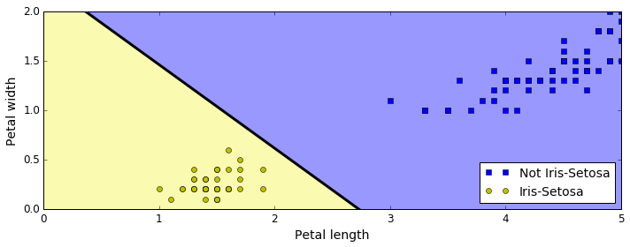

```python
a = -per_clf.coef_[0][0] / per_clf.coef_[0][1]
b = -per_clf.intercept_ / per_clf.coef_[0][1]

axes = [0, 5, 0, 2]

x0, x1 = np.meshgrid(
        np.linspace(axes[0], axes[1], 500).reshape(-1, 1),
        np.linspace(axes[2], axes[3], 200).reshape(-1, 1),
    )
X_new = np.c_[x0.ravel(), x1.ravel()]
y_predict = per_clf.predict(X_new)
zz = y_predict.reshape(x0.shape)

plt.figure(figsize=(10, 4))
plt.plot(X[y==0, 0], X[y==0, 1], "bs", label="Not Iris-Setosa")
plt.plot(X[y==1, 0], X[y==1, 1], "yo", label="Iris-Setosa")

plt.plot([axes[0], axes[1]], [a * axes[0] + b, a * axes[1] + b], "k-", linewidth=3)
from matplotlib.colors import ListedColormap
custom_cmap = ListedColormap(['#9898ff', '#fafab0'])

plt.contourf(x0, x1, zz, cmap=custom_cmap, linewidth=5)
plt.xlabel("Petal length", fontsize=14)
plt.ylabel("Petal width", fontsize=14)
plt.legend(loc="lower right", fontsize=14)
plt.axis(axes)

save_fig("perceptron_iris_plot")
plt.show()
```

Perceptron 학습 알고리즘은 Stochastic Gradient Descent와 매우 유사하다. 실제로 scikit-learn의 Perceptron 클래스는 loss='perceptron',learning_rate='constant',eta0=1,그리고 penalty=None과 같은 hyperparameter와 함께 SGDClassifier를 사용하는 것과 같다.

Logistic Regression분류기와 달리, 퍼셉트론은 클래스 확률을 출력하지 않는다. 그들은 단지 hard threshold 값을 기반으로 예측을 실시한다.

이러한 이유로 Logistic regression이 퍼셉트론보다 선호된다.

Perceptrons라는 제목의 1969년 논문에서 Marvin과 Seymour는 퍼셉트론의 약점, 특히 exclusive OR문제를 해결할 수 없다는 사실을 강조했다.

결과적으로 많은 연구자들이 논리, 문제해결 및 검색과 같은 더 높은 수준의 문제를 선호하는 connectionism(즉, 신경망연구)을 중단했다.

그러나 여러가지 퍼셉트론을 stacking하면 퍼셉트론의 한계점 중 일부를 제거할 수 있다. 이런 결과를 MLP(Multi-Layer Perceptron)라고 부른다.

입력 (0,0) 또는 (1,1)네트워크는 0을 출력하고, 입력(0,1) 또는 (1,0)네트워크는 1을 출력한다.

## Multi-Layer Perceptron and Backpropagation

MLP는 하나의 input layer와 hidden layer라 불리는 하나 이상의 LTU layer와, output layer라 불리는 LTU의 최종 layer로 구성된다.

output layer를 제외한 모든 layer는 bias neuron을 포함하며, 다음 layer에 완전히 연결된다.

ANN(인공신경망)에 두개 이상의 hidden layer가 있을 경우, 이를 DNN(Deep Neural Network)라고 한다.

MLP를 학습하기 위한 방법인 backpropagation training algorithm이 1986년에 소개되었다.

이것을 reverse-mode autodiff를 이용하여 Gradient Descent로 설명하면, 1.각 학습 인스턴스에 대해, 알고리즘은 네트워크에 feed하고 각 연속 layer의 모든 뉴런의 output을 계산한다. 2.다음으로 네트워크의 output error를 측정하고, 마지막 hidden layer의 각 뉴런이 각각의 output neuron's error에 얼마나 기여했는지 계산한다. 3.그 다음 이러한 error가 이전의 hidden layer의 각 뉴런으로부터 얼마나 기여했는지를 측정한다. 알고리즘이 input layer에 도달할 때까지 계속된다.

이러한 reverse pass는 네트워크에서 역방향으로 error gradient를 전파함으로써 네트워크의 모든 연결 가중치에 대한 error gradient를 효율적으로 측정한다.

역전파 알고리즘의 마지막 단계는 앞에서 측정한 error gradient를 사용하여 네트워크의 모든 연결 가중치에 대한 Gradient Descent 단계이다.

위에 길게 나열한 것을 짧게 설명하면, 각각의 training instance에 대해 역전파 알고리즘은 먼저 예측을 진행하고, 오류를 측정한 다음, 역으로 각 layer를 거쳐 각 연결에서 error 기여도를 측정하고, 마지막으로 error를 줄이기위해 연결 가중치를 미세하게 조정한다.

이 알고리즘을 제대로 작동시키기 위해서, 저자는 MLP의 아키텍쳐를 변경하였다. step function을 Logistic function으로 대체했다. step function은 flat segment로만 구성되어 있기 때문에, Gradient Descent는 평평한 표면에서 움직일 수 없어서 대체가 필수적이다.

두 개의 다른 활성화 함수는 다음과 같다.

1)The hyperbolic tangent function "tanh" -Logistic function과 마찬가지로 S자 형이고 연속적이며 미분 가능하지만 출력 값의 범위는 -1부터 1까지이다. -각 layer의 출력이 학습 시작 시, 정규화되도록 하는 경향이 있다. -이것은 수렴 속도를 높이는 데 종종 도움이 된다.

2)The "ReLU" function -이것은 연속적이지만 z=0일 때 미분 불가능하다. -실제로 매우 잘 작동하며, 계산 속도가 빠른 장점이 있다. -최대 출력 값을 가지고 있지 않다는 사실은 gradient descent동안 일부 문제를 줄이는 데 도움이 된다.

```python
def logit(z):
    return 1 / (1 + np.exp(-z))

def relu(z):
    return np.maximum(0, z)

def derivative(f, z, eps=0.000001):
    return (f(z + eps) - f(z - eps))/(2 * eps)
```

```
Saving figure activation_functions_plot
```

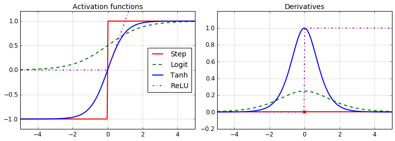

```python
z = np.linspace(-5, 5, 200)

plt.figure(figsize=(11,4))

plt.subplot(121)
plt.plot(z, np.sign(z), "r-", linewidth=2, label="Step")
plt.plot(z, logit(z), "g--", linewidth=2, label="Logit")
plt.plot(z, np.tanh(z), "b-", linewidth=2, label="Tanh")
plt.plot(z, relu(z), "m-.", linewidth=2, label="ReLU")
plt.grid(True)
plt.legend(loc="center right", fontsize=14)
plt.title("Activation functions", fontsize=14)
plt.axis([-5, 5, -1.2, 1.2])

plt.subplot(122)
plt.plot(z, derivative(np.sign, z), "r-", linewidth=2, label="Step")
plt.plot(0, 0, "ro", markersize=5)
plt.plot(0, 0, "rx", markersize=10)
plt.plot(z, derivative(logit, z), "g--", linewidth=2, label="Logit")
plt.plot(z, derivative(np.tanh, z), "b-", linewidth=2, label="Tanh")
plt.plot(z, derivative(relu, z), "m-.", linewidth=2, label="ReLU")
plt.grid(True)
#plt.legend(loc="center right", fontsize=14)
plt.title("Derivatives", fontsize=14)
plt.axis([-5, 5, -0.2, 1.2])

save_fig("activation_functions_plot")
plt.show()
```

```python
def heaviside(z):
    return (z >= 0).astype(z.dtype)

def sigmoid(z):
    return 1/(1+np.exp(-z))

def mlp_xor(x1, x2, activation=heaviside):
    return activation(-activation(x1 + x2 - 1.5) + activation(x1 + x2 - 0.5) - 0.5)
```

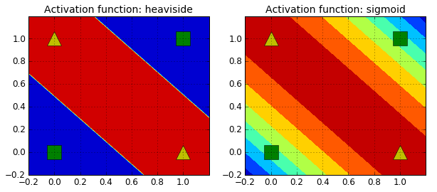

```python
x1s = np.linspace(-0.2, 1.2, 100)
x2s = np.linspace(-0.2, 1.2, 100)
x1, x2 = np.meshgrid(x1s, x2s)

z1 = mlp_xor(x1, x2, activation=heaviside)
z2 = mlp_xor(x1, x2, activation=sigmoid)

plt.figure(figsize=(10,4))

plt.subplot(121)
plt.contourf(x1, x2, z1)
plt.plot([0, 1], [0, 1], "gs", markersize=20)
plt.plot([0, 1], [1, 0], "y^", markersize=20)
plt.title("Activation function: heaviside", fontsize=14)
plt.grid(True)

plt.subplot(122)
plt.contourf(x1, x2, z2)
plt.plot([0, 1], [0, 1], "gs", markersize=20)
plt.plot([0, 1], [1, 0], "y^", markersize=20)
plt.title("Activation function: sigmoid", fontsize=14)
plt.grid(True)
```

# FNN for MNIST

MLP는 종종 분류에 사용되며 각 출력은 다른 바이너리 클래스에 해당된다. 클래스가 배타적이면 output layer는 일반적으로 개별 활성화 함수를 softmax 함수로 대체하여 수정된다. 각 뉴런의 출력은 해당 클래스의 예상 확률에 해당된다. 신호는 입력에서 출력으로 한 방향으로만 흐른다. 따라서 이 아키텍쳐는 FNN(Feedforward Neural Network)의 예이다.

## using tf.learn

텐서플로우를 사용하여 MLP를 학습하는 가장 간단한 방법은 scikit-learn-compatible API를 제공하는 높은 수준의 API인 TF.Learn을 사용하는 것이다. DNNClassifier 클래스를 사용하면 hidden layer를 여러 개 사용하여 deep neural network를 쉽게 학습할 수 있고,예상되는 클래스 확률을 출력할 softmax output layer를 만들 수 있다.

```python
# 두 개의 hidden layer와 10개의 뉴런을 가지고 있는 softmax output layer로 분류되도록 DNN 학습.
from tensorflow.examples.tutorials.mnist import input_data

mnist = input_data.read_data_sets("/tmp/data/")
```

```
Extracting /tmp/data/train-images-idx3-ubyte.gz
Extracting /tmp/data/train-labels-idx1-ubyte.gz
Extracting /tmp/data/t10k-images-idx3-ubyte.gz
Extracting /tmp/data/t10k-labels-idx1-ubyte.gz
```

```python
X_train = mnist.train.images
X_test = mnist.test.images
y_train = mnist.train.labels.astype("int")
y_test = mnist.test.labels.astype("int")
```

```python
import tensorflow as tf

config = tf.contrib.learn.RunConfig(tf_random_seed=42) # not shown in the config

feature_cols = tf.contrib.learn.infer_real_valued_columns_from_input(X_train)
dnn_clf = tf.contrib.learn.DNNClassifier(hidden_units=[300,100], n_classes=10,
                                         feature_columns=feature_cols, config=config)
dnn_clf = tf.contrib.learn.SKCompat(dnn_clf) # if TensorFlow >= 1.1
dnn_clf.fit(X_train, y_train, batch_size=50, steps=40000)
```

[output not shown]

[output cut: 756 more lines]

[output not shown]

```
SKCompat()
```

위의 코드는 training set에서 실제 가치가 있는 열 집합을 만든다. 그 다음 DNNClassifier를 만들고, scikit-learn compatibility helper로 묶는다. 마지막으로 50개의 인스턴스의 batch를 이용하여 40000번의 반복학습한다.

```python
from sklearn.metrics import accuracy_score

y_pred = dnn_clf.predict(X_test)
accuracy_score(y_test, y_pred['classes'])
```

```
INFO:tensorflow:Restoring parameters from /tmp/tmpecewk7kb/model.ckpt-40000
```

```
0.98250000000000004
```

```python
from sklearn.metrics import log_loss

y_pred_proba = y_pred['probabilities']
log_loss(y_test, y_pred_proba)
```

```
0.071487383848950564
```

DNNClassifier클래스는 ReLU 활성화 함수를 기반으로 모든 뉴런 layer를 만든다. output layer는 softmax함수에 의존하고, cost function은 cross-entropy이다.

## Using plain TensorFlow

네트워크 아키텍쳐를 잘 제어하려면, 텐서플로우의 저수준 파이썬 API를 사용하는 것이 좋다.

이번에는 이 API를 사용하기전과 동일한 모델을 만들고 MNIST 데이터셋에서 Mini-batch Gradient Descent를 구현한다.

첫 번째 단계는 텐서플로우 그래프를 만드는 construction phase이다.

두 번째 단계는 실제로 그래프를 실행하여 모델을 학습하는 execution phase이다.

## Construction Phase

```python
#입력 및 출력 수를 지정하고, 각 계층에서 hidden neuron의 수를 설정.
import tensorflow as tf

n_inputs = 28*28  # MNIST
n_hidden1 = 300
n_hidden2 = 100
n_outputs = 10
```

우리는 첫 번째 차원의 인스턴스와 두 번째 차원의 feature를 갖는 2차원 텐서(행렬)라는 것을 알 수 있다. 또한, feature의 개수는 28X28 이라는 것을 알 수 있다.

```python
reset_graph()

X = tf.placeholder(tf.float32, shape=(None, n_inputs), name="X")
y = tf.placeholder(tf.int64, shape=(None), name="y")
```

```python
#실제 신경망 만드는 코드

def neuron_layer(X, n_neurons, name, activation=None):
    with tf.name_scope(name):
        n_inputs = int(X.get_shape()[1])
        stddev = 2 / np.sqrt(n_inputs)
        init = tf.truncated_normal((n_inputs, n_neurons), stddev=stddev)
        W = tf.Variable(init, name="kernel")
        b = tf.Variable(tf.zeros([n_neurons]), name="bias")
        Z = tf.matmul(X, W) + b
        if activation is not None:
            return activation(Z)
        else:
            return Z

# placeholder X는 input layer로 작동한다.
```

1)layer이름을 사용하여 name scope를 만든다. 이 layer에서 뉴런 layer에 대한 모든 계산 노드가 포함된다.

2)다음으로 입력행렬의 shape에서 두번째 차원의 크기를 불러와서 input의 수를 얻는다.

3)다음 세 줄은 가중치 행렬을 hold할 변수 W를 만든다. 각 입력과 각 뉴런사이의 모든 연결 가중치를 포함하는 2차원 텐서이다. 특정 표준편차를 사용하면 알고리즘이 훨씬 빨리 수렴하는 데 도움이 된다.

4)0으로 초기화 된 bias에 대한 변수b를 만든다. 뉴런 당 하나의 bias 파라미터가 있다.

5)그 다음 Z=XW+b 를 계산하기 위한 부분 그래프를 만든다.

6)마지막으로 tf.nn.relu와 같은 활성화 파라미터가 제공되면, 코드는 활성화(Z)를 반환하거나 그렇지 않으면 Z만 반환한다.

```python
with tf.name_scope("dnn"):
    hidden1 = neuron_layer(X, n_hidden1, name="hidden1",
                           activation=tf.nn.relu)
    hidden2 = neuron_layer(hidden1, n_hidden2, name="hidden2",
                           activation=tf.nn.relu)
    logits = neuron_layer(hidden2, n_outputs, name="outputs")
```

위 코드에서 첫 번째 hidden layer는 X를 입력으로 사용한다. 두 번째 hidden layer는 첫 번째 hidden layer의 출력을 입력으로 사용한다. 마지막 output layer는 두 번째 hidden layer의 출력을 입력으로 사용한다.

logits는 softmax 활성화 함수를 거치기 전에 neural network의 output이다.

```python
# 신경망 모델을 학습시키는 데 사용할 비용함수 정의.
with tf.name_scope("loss"):
    xentropy = tf.nn.sparse_softmax_cross_entropy_with_logits(labels=y,
                                                              logits=logits)
    loss = tf.reduce_mean(xentropy, name="loss")
```

```python
learning_rate = 0.01

with tf.name_scope("train"):
    optimizer = tf.train.GradientDescentOptimizer(learning_rate)
    training_op = optimizer.minimize(loss)
```

```python
# 모델 평가방법 지정.
with tf.name_scope("eval"):
    correct = tf.nn.in_top_k(logits, y, 1)
    accuracy = tf.reduce_mean(tf.cast(correct, tf.float32))
```

```python
# 모든 변수 초기화하는 노드 생성.
init = tf.global_variables_initializer()
saver = tf.train.Saver()
```

Construction Phase에서 input과 targer에 대한 placeholder를 만들었고, neuron layer를 만드는 함수를 만들고, DNN을 만들기 위해 비용함수를 정의하고, 최적화 도구를 만들었고, 마지막으로 성능 측정을 정의하였다.

## Execution Phase

```python
# 실행하려는 epoch의 수와 mini-batch의 크기 정의.
n_epochs = 40
batch_size = 50
```

```python
with tf.Session() as sess:
    init.run()
    for epoch in range(n_epochs):
        for iteration in range(mnist.train.num_examples // batch_size):
            X_batch, y_batch = mnist.train.next_batch(batch_size)
            sess.run(training_op, feed_dict={X: X_batch, y: y_batch})
        acc_train = accuracy.eval(feed_dict={X: X_batch, y: y_batch})
        acc_val = accuracy.eval(feed_dict={X: mnist.validation.images,
                                            y: mnist.validation.labels})
        print(epoch, "Train accuracy:", acc_train, "Val accuracy:", acc_val)

    save_path = saver.save(sess, "./my_model_final.ckpt")
```

```
0 Train accuracy: 0.9 Val accuracy: 0.9146
1 Train accuracy: 0.94 Val accuracy: 0.9348
2 Train accuracy: 0.92 Val accuracy: 0.9466
3 Train accuracy: 0.96 Val accuracy: 0.9508
4 Train accuracy: 0.92 Val accuracy: 0.9586
5 Train accuracy: 0.94 Val accuracy: 0.9584
6 Train accuracy: 0.98 Val accuracy: 0.9608
7 Train accuracy: 0.96 Val accuracy: 0.9636
8 Train accuracy: 0.92 Val accuracy: 0.9638
9 Train accuracy: 0.96 Val accuracy: 0.965
10 Train accuracy: 0.98 Val accuracy: 0.9686
11 Train accuracy: 0.94 Val accuracy: 0.9686
12 Train accuracy: 1.0 Val accuracy: 0.9702
13 Train accuracy: 0.94 Val accuracy: 0.9686
14 Train accuracy: 1.0 Val accuracy: 0.9716
```

[output cut: 25 more lines]

```python
with tf.Session() as sess:
    saver.restore(sess, "./my_model_final.ckpt") # or better, use save_path
    X_new_scaled = mnist.test.images[:20]
    Z = logits.eval(feed_dict={X: X_new_scaled})
    y_pred = np.argmax(Z, axis=1)
```

```
INFO:tensorflow:Restoring parameters from ./my_model_final.ckpt
```

위의 코드에서 모든 예측된 클래스의 확률을 알고싶다면 softmax()함수를 logits에 적용해야되지만, 단지 클래스를 예측하기를 원한다면 argmax()함수를 이용하면 된다.

```python
print("Predicted classes:", y_pred)
print("Actual classes:   ", mnist.test.labels[:20])
```

```
Predicted classes: [7 2 1 0 4 1 4 9 6 9 0 6 9 0 1 5 9 7 3 4]
Actual classes:    [7 2 1 0 4 1 4 9 5 9 0 6 9 0 1 5 9 7 3 4]
```

```python
from IPython.display import clear_output, Image, display, HTML

def strip_consts(graph_def, max_const_size=32):
    """Strip large constant values from graph_def."""
    strip_def = tf.GraphDef()
    for n0 in graph_def.node:
        n = strip_def.node.add()
        n.MergeFrom(n0)
        if n.op == 'Const':
            tensor = n.attr['value'].tensor
            size = len(tensor.tensor_content)
            if size > max_const_size:
                tensor.tensor_content = b"<stripped %d bytes>"%size
    return strip_def

def show_graph(graph_def, max_const_size=32):
    """Visualize TensorFlow graph."""
    if hasattr(graph_def, 'as_graph_def'):
        graph_def = graph_def.as_graph_def()
    strip_def = strip_consts(graph_def, max_const_size=max_const_size)
    code = """
        <script>
          function load() {{
            document.getElementById("{id}").pbtxt = {data};
          }}
        </script>
        <link rel="import" href="https://tensorboard.appspot.com/tf-graph-basic.build.html" onload=load()>
        <div style="height:600px">
          <tf-graph-basic id="{id}"></tf-graph-basic>
        </div>
    """.format(data=repr(str(strip_def)), id='graph'+str(np.random.rand()))

    iframe = """
        <iframe seamless style="width:1200px;height:620px;border:0" srcdoc="{}"></iframe>
    """.format(code.replace('"', '&quot;'))
    display(HTML(iframe))
```

```python
show_graph(tf.get_default_graph())
```

[interactive chart not shown]

## Using `dense()` instead of `neuron_layer()`

```python
n_inputs = 28*28  # MNIST
n_hidden1 = 300
n_hidden2 = 100
n_outputs = 10
```

```python
reset_graph()

X = tf.placeholder(tf.float32, shape=(None, n_inputs), name="X")
y = tf.placeholder(tf.int64, shape=(None), name="y")
```

```python
with tf.name_scope("dnn"):
    hidden1 = tf.layers.dense(X, n_hidden1, name="hidden1",
                              activation=tf.nn.relu)
    hidden2 = tf.layers.dense(hidden1, n_hidden2, name="hidden2",
                              activation=tf.nn.relu)
    logits = tf.layers.dense(hidden2, n_outputs, name="outputs")
```

```python
with tf.name_scope("loss"):
    xentropy = tf.nn.sparse_softmax_cross_entropy_with_logits(labels=y, logits=logits)
    loss = tf.reduce_mean(xentropy, name="loss")
```

```python
learning_rate = 0.01

with tf.name_scope("train"):
    optimizer = tf.train.GradientDescentOptimizer(learning_rate)
    training_op = optimizer.minimize(loss)
```

```python
with tf.name_scope("eval"):
    correct = tf.nn.in_top_k(logits, y, 1)
    accuracy = tf.reduce_mean(tf.cast(correct, tf.float32))
```

```python
init = tf.global_variables_initializer()
saver = tf.train.Saver()
```

```python
n_epochs = 20
n_batches = 50

with tf.Session() as sess:
    init.run()
    for epoch in range(n_epochs):
        for iteration in range(mnist.train.num_examples // batch_size):
            X_batch, y_batch = mnist.train.next_batch(batch_size)
            sess.run(training_op, feed_dict={X: X_batch, y: y_batch})
        acc_train = accuracy.eval(feed_dict={X: X_batch, y: y_batch})
        acc_test = accuracy.eval(feed_dict={X: mnist.test.images, y: mnist.test.labels})
        print(epoch, "Train accuracy:", acc_train, "Test accuracy:", acc_test)

    save_path = saver.save(sess, "./my_model_final.ckpt")
```

```
0 Train accuracy: 0.9 Test accuracy: 0.9053
1 Train accuracy: 0.88 Test accuracy: 0.9206
2 Train accuracy: 0.94 Test accuracy: 0.9301
3 Train accuracy: 0.94 Test accuracy: 0.9397
4 Train accuracy: 0.92 Test accuracy: 0.9451
5 Train accuracy: 0.94 Test accuracy: 0.9476
6 Train accuracy: 0.92 Test accuracy: 0.9515
7 Train accuracy: 0.98 Test accuracy: 0.9546
8 Train accuracy: 0.96 Test accuracy: 0.9569
9 Train accuracy: 0.94 Test accuracy: 0.9605
10 Train accuracy: 0.92 Test accuracy: 0.9619
11 Train accuracy: 0.96 Test accuracy: 0.9631
12 Train accuracy: 1.0 Test accuracy: 0.9661
13 Train accuracy: 0.94 Test accuracy: 0.9657
14 Train accuracy: 1.0 Test accuracy: 0.9669
15 Train accuracy: 0.94 Test accuracy: 0.9682
16 Train accuracy: 0.96 Test accuracy: 0.9701
17 Train accuracy: 0.98 Test accuracy: 0.9696
18 Train accuracy: 1.0 Test accuracy: 0.97
19 Train accuracy: 1.0 Test accuracy: 0.971
```

```python
show_graph(tf.get_default_graph())
```

[interactive chart not shown]

# Fine-Tuning Neural Network Hyperparameters

신경망의 유연성은 주요 단점 중 하나이다. 그리고 그것을 조정하기 위한 많은 파라미터들이 있다.

간단한 MLP에서도 layer의 수, layer당 뉴런의 수, 각 layer에서 사용할 활성화 함수 유형, 가중치 초기화 로직 등 변경할 수 있다.

교차 검증과 함께 그리드 서치를 이용하여 올바른 파라미터를 찾을 수 있다. 하지만 조정해야 할 매개변수가 많고, 대규모 데이터 셋에서 신경망을 학습하는 데 많은 시간이 걸린다. 2장에서 설명한 것처럼 randomized search을 사용하는 것이 좋다. 또 다른 옵션은 Oscar와 같은 도구를 사용하는 것이다. 이 도구는 더 복잡한 알고리즘을 구현하여 훌륭한 파라미터 집합을 빠르게 찾을 수 있도록 해준다.

### Number of Hidden Layers

계층적 아키텍쳐는 DNN이 보다 신속하게 좋은 솔루션으로 수렴할 수 있을뿐만 아니라 새로운 데이터 세트에서 일반화 할 수 있는 능력을 향상시킨다.

예를들어, 얼굴을 인식할 수 있는 모델을 학습한다고 가정할 때 새로운 신경망을 학습하여 헤어스타일을 인식하고 싶다면 처음부터 다시 배우지 않아도 된다.

많은 문제에 대해 하나 또는 두개의 hidden layer로 시작할 수 있다.대략 동일한 양의 뉴런을 가진 두 개의 hidden layer를 사용하여 대략 98%의 정확도를 얻을 수 있다.

좀 더 복잡한 문제의 경우, 학습 셋이 overfitting될 때까지 hidden layer의 수를 점차적으로 늘릴 수 있다. 큰 이미지 분류나 음성인식과 같은 복잡한 작업에는 일반적으로 수십 개의 layer가 있는 네트워크가 필요하다. 하지만 이 네트워크를 처음부터 학습할 필요는 거의 없다. 유사한 작업을 수행하는 미리 학습 된 최신의 네트워크의 일부를 재사용하는 것이 훨씬 더 일반적이다.

### Number of Neurons per Hidden Layer

Input/Output layer의 뉴런 수는 작업에 필요한 input/output의 유형에 따라 결정된다.

Layer의 수와 마찬가지로 네트워크가 overfitting이 될 때까지 점차적으로 뉴런의 수를 늘릴 수 있다.